# T06. BLAST

## Alineamientos locales

1. Pares de segmentos con puntuación máxima.
2. La puntuación *S* de un alineamiento depende de:
   - La matriz de puntuación.
   - El esquema de puntuación de los *gaps*
3. ¿Cuál es la distribución de *S* en pares aleatorios de secuencias?

## ¿Qué significa *aleatorias*?

1. Pares de secuencias reales pero no homólogas.
2. Permutaciones de los residuos de secuencias reales.
3. Simulación de secuencias a partir de un modelo.

Entonces, ¿Cuál es la distribución de *S*?

1. Si sólo usamos alineamientos **sin** *gaps*.
2. Si la puntuación esperada al azar es negativa.

Se puede demostrar (Karlin and Altschul 1990) que:

$$P(S < x) = e^{-Kmne^{-\lambda x}}$$

- *S*: puntuación del **mejor** alineamiento local entre dos secuencias.
- *m* y *n*: longitudes de las secuencias.
- *K* y $\lambda$: parámetros que dependen de la composición de las secuencias y del sistema de puntuación.

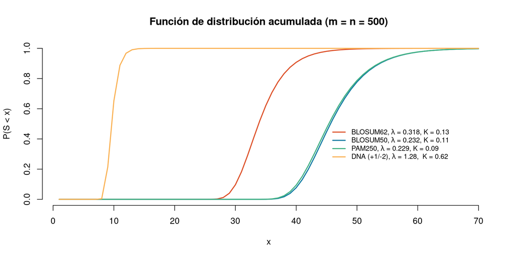

Los alineamientos de ADN obtienen puntuaciones menores. Cuanto mayor es la divergencia admitida por la matriz de puntuación, mayor es la puntuación esperada.

## Valor *E*

Número esperado de alineamientos con una puntuación de al menos *S*:

$$E = Kmne^{-\lambda S}$$
Cuanto **menor** es *E*, más significativo es el alineamiento.

## *Bitscore*

Es una normalización de la puntuación *S*, que ya no depende del esquema de puntuación, y tiene las mismas unidades en todas las búsquedas:

$$S' = \frac{\lambda S - \log K}{\log 2}$$

$$E = mn2^{-S'}$$

## Valor *p*

Probabilidad de observar una puntuación mayor o igual a *S* por casualidad:

$$p = 1 - e^{-E}$$

Se deriva del hecho de que el número de alineamientos aleatorios con puntuación mayor o igual a *S* sigue una distribución de Poisson.

## Cómo funciona

1. Detecta e ignora regiones repetitivas o de *baja complejidad* de la *query*.
2. Hace una lista de palabras de *k* letras de la *query* (*k* = 11 para DNA):

   ```
                         PQGEFG
                         PQG
                          QGE
                           GEF
                            EFG
   ```

3. Añade a la lista palabras *vecinas* que alinearían con puntuación de al menos *T*.

## Cómo funciona

4. Busca las palabras de la lista entre las secuencias de la base de datos (indexadas).

5. Alarga la *semilla* de los alineamientos encontrados (*High-scoring Segment Pair*, HSP).

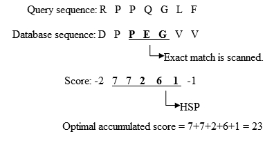

## Cómo funciona

6. Enumera HSPs con puntuación mayor de la que se produciría por azar.

7. Evalúa la significación de los HSPs.

8. Combina dos o más HSP en uno.

9. Muestra el alineamiento local Smith-Waterman de cada resultado.

10. Enumera los resultados con valor *E* menor o igual a un cierto umbral.

## Principales programas

| Programa | Query | Base.de.datos |
| --- | --- | --- |
| blastn | DNA | DNA |
| blastp | proteína | proteína |
| blastx | DNA | proteína |
| tblastn | proteína | DNA |
| tblastx | DNA | DNA |

## PSI-BLAST

| GAGGTAAAC |
| --- |
| TCCGTAAGT |
| CAGGTTGGA |
| ACAGTCAGT |
| TAGGTCATT |
| TAGGTACTG |
| ATGGTAACT |
| CAGGTATAC |
| TGTGTGAGT |
| AAGGTAAGT |

### PSSM

| A | 0.25 | 1.23 | -1.24 | -4.70 | -4.70 | 1.23 | 1.45 | -0.31 | -1.24 |
| --- | --- | --- | --- | --- | --- | --- | --- | --- | --- |
| C | -0.31 | -0.31 | -1.24 | -4.70 | -4.70 | -0.31 | -1.24 | -1.24 | -0.31 |
| G | -1.24 | -1.24 | 1.45 | 1.96 | -4.70 | -1.24 | -1.24 | 0.97 | -1.24 |
| T | 0.66 | -1.24 | -1.24 | -4.70 | 1.96 | -1.24 | -1.24 | -0.31 | 1.23 |

Ejemplo de *Position Specific Scoring Matrix*

## PSI-BLAST

[figure not shown]

El PSI-BLAST empieza como un BLASTP (1). A partir del alineamiento de las secuencias homólogas que superan el umbral de valor E, genera una PSSM (2). Y utiliza la PSSM como nueva consulta (query) para añadir secuencias homólogas al alineamiento y repetir el ciclo.

## [PSI-BLAST](https://www.ebi.ac.uk/Tools/sss/psiblast/)

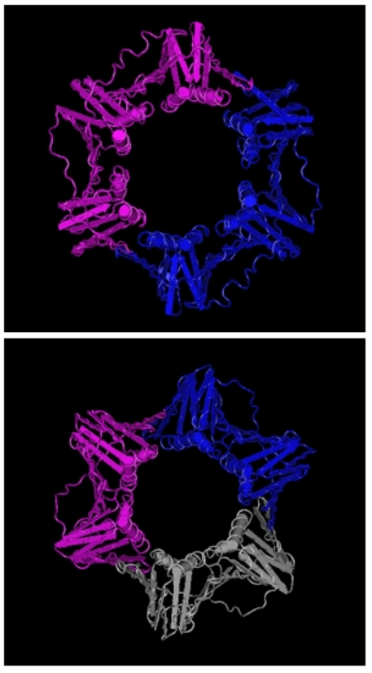

(Humana Press, 2007)

## BLAST en la web

### [NCBI BLAST](https://blast.ncbi.nlm.nih.gov/Blast.cgi)

### [EMBL-EBI BLAST](https://www.ebi.ac.uk/Tools/sss/ncbiblast/)

Existe tamién un paquete de programas `blast` para línea de comandos que utilizaremos en prácticas.

## Referencias

Karlin, S., and S. F. Altschul. 1990. “Methods for Assessing the Statistical Significance of Molecular Sequence Features by Using General Scoring Schemes.” *Proc. Natl. Acad. Sci. USA* 87: 22674–268.